# Automate All the Things

Erin M. Buchanan

2023-04-15

# Outline

- What and Why Markdown
- The parts of a Markdown doc
- Options to tweak documents
- Options for output

# What is Markdown?

- “Markdown is a lightweight markup language for creating formatted text using a plain-text editor”
- “Markdown is a lightweight markup language that you can use to add formatting elements to plain text text documents.”
- “R Markdown provides an authoring framework for data science.”
- In short, it’s a set of simple codes that help us transform text into formatted documents.

# Flavors? Is this Ice Cream?

- Markdown has multiple “flavors”
- A good analogy is language dialect
- R Markdown is for R, GitHub uses similar version and so on

# Why should I use it?

- You can create many types of things in markdown:
  - Websites
  - Books
  - Academic/scientific reports
  - Presentations (like this one!)
  - and more!

# Why should I use it?

- Portable: since it is text, you can open it in many ways
- Platform independent: *technically* since it’s raw text
- Lots of people use it, so the skill transfers to unexpected places (Reddit, Slack)

# Why should I use programming markdown?

- Things like *R* markdown, Jupyter notebooks, Quarto, …
- You can integrate text and code into the same document!
- You can create reproducible reports
- You can annotate your notes with reminders for later
- Put everything in one place!
- Have more control over documents
- Cut and paste errors minimized

# How it works

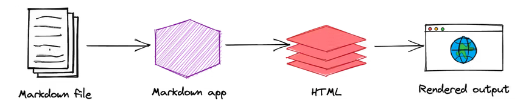

# Some Useful Rmd Links

- https://raw.githubusercontent.com/rstudio/cheatsheets/main/rmarkdown-2.0.pdf
- https://www.rstudio.com/wp-content/uploads/2015/03/rmarkdown-reference.pdf
- https://bookdown.org/yihui/rmarkdown-cookbook/

# What do I need?

- *R*, *RStudio* (software)
- LaTeX for PDF documents

```r
install.packages("tinytex")
tinytex::install_tinytex()
```

- Word or something like it (Libre, OpenOffice) for DOC(X)
- Powerpoint for PPT(X)

# Other Packages

- For today:

```r
install.packages(c("rmarkdown", "knitr", "flextable", "dplyr",
                   "rio", "ggplot2", "ggthemes", "treemapify"))
```

- Specific goals:
  - `papaja` is great for APA journal articles, and `rticles` has many journal article templates
  - `bookdown` and `blogdown` for building open source text books and websites with markdown
  - `officedown` and `officer` for Word document formatting

# Let’s Get Started!

- Let’s create a markdown template to show off the components
- File > New File > Rmarkdown

[figure not shown]

# Let’s Get Started!

- Select your desired output (start with HTML)
- Enter a title
- Pick a template if you want
- Create!

[figure not shown]

# Rmd Document Parts - YAML

- yet another markup language
- Header of your document
- The way you can control the type and options for the overall document

```
---
title: "Untitled"
author: "Erin M. Buchanan"
date: "2023-04-15"
output: html_document
---
```

# Rmd Document Parts - YAML

- A note about YAMLs: it is *very* picky about indentation
- YAML depends on the output options you pick
- Let’s try a few of them out
- “Knit” the document in html format to get an idea of what this looks like when you start

# Knitting

- *The most important thing to remember*: when you hit knit, **everything** you have in your environment is ignored
  - You start with a blank slate
  - You must load the libraries in the markdown
  - The order matters!
- Other things learned the hard way
  - Don’t put `View()` in a markdown
  - Don’t install packages in a markdown
  - Watch out for funky symbols

# HTML - YAML

- Add a table of contents

```
output:
  html_document:
    toc: true
    toc_depth: 2
```

# HTML - YAML

- Floating table of contents

```
output:
  html_document:
    toc: true
    toc_float: true
```

```
output:
  html_document:
    toc: true
    toc_float:
      collapsed: false
      smooth_scroll: false
```

# HTML - YAML

- Number your sections

```
output:
  html_document:
    number_sections: true
```

# HTML - YAML

- `theme`: here are the options default, bootstrap, cerulean, cosmo, darkly, flatly, journal, lumen, paper, readable, sandstone, simplex, spacelab, united, and yeti
- `highlight`: `default`, `tango`, `pygments`, `kate`, `monochrome`, `espresso`, `zenburn`, `haddock`, `breezedark`, and `textmate`
- `code_folding: hide` or `code_folding: show` allow you to show your code but enable people to hide it

```
output:
  html_document:
    theme: united
    highlight: tango
```

# PDF - YAML

- Many of the same features still work
- Tables of contents, code highlighting
- Options for the Pandoc engines (aka how it knits)

# Word - YAML

- Many of the same features still work
- Tables of contents, code highlighting
- Best feature: creating a custom style

```
output:
  word_document:
    reference_docx: my-styles.docx
```

# Rmd Document Parts - Narrative

- Any section you write raw text
- You can add the official markdown here
- You can add LaTeX to create fancy equations and symbols $\beta$
- You can use raw LaTeX or HTML that will be converted
- And more!

```
## R Markdown

This is an R Markdown document. Markdown is a simple formatting syntax for authoring HTML, PDF, and MS Word documents. For more details on using R Markdown see <http://rmarkdown.rstudio.com>.

When you click the **Knit** button a document will be generated that includes both content as well as the output of any embedded R code chunks within the document. You can embed an R code chunk like this:
```

# Rmd Document Parts - Narrative

- A note about spacing: you have to leave a *blank* line between items if you want to make a new paragraph
- What are the most common things we can add?
- Text styling, links, citations and more

# Narrative - Headers/Blocks

```markdown
# First-level header

## Second-level header

### Third-level header
```

# Narrative - Text Styles

# Narrative - Lists

- You can make numbered or bulleted lists

```
- one item
- one item
- one item
    - one more item
    - one more item
    - one more item
```

# Narrative - Citations

- There are a few ways to enter citations but generally are listed as `@citationname`
- This `@citationname` is found stored in a separate `.bib`. file that might have an entry like this:

```
@Manual{R-base,
  title = {R: A Language and Environment for Statistical
    Computing},
  author = {{R Core Team}},
  organization = {R Foundation for Statistical Computing},
  address = {Vienna, Austria},
  year = {2017},
  url = {https://www.R-project.org/},
}
```

# Narrative - Citations

- How can I create the bib file or organize the citations?
- You can use a free/paid manager like Zotero or Endnote
- You can export them from the journal website
- You can let RStudio do it for you with the `Visual` editor

# Narrative - Citations

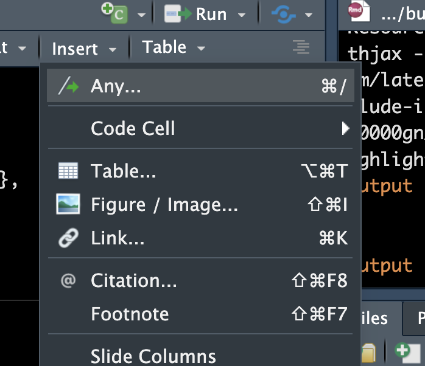

# Narrative - Citations

[figure not shown]

# Narrative - Citations

- You can also just start typing into the text in the Visual editor

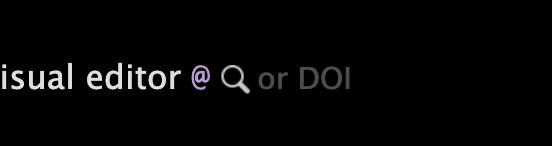

# Narrative - Citations

# Narrative - Citations

- Default citation style is to put them in to Chicago at the end of the document
- To change this, use the YAML and add a `.csl` file
- Put this file into the same folder as the markdown
- You can find a ton of them at https://www.zotero.org/styles

```
---
output: html_document
bibliography: references.bib
csl: biomed-central.csl
---
```

# Narrative - Tabbed Sections

- I asked the internet what they thought was cool - tabsets!
- If you use the `{.tabset}` class, you can organize output into tabs that fall under that subheader

```
## Quarterly Results {.tabset}

### By Product

(tab content)

### By Region

(tab content)
```

- Two other cool features:

```markdown
## Quarterly Results {.tabset .tabset-fade .tabset-pills}
```

# Rmd Document Parts - Code Chunks

- You can add code in the middle of narrative sections as a *chunk* or as an *inline* section.
- *Chunks* have three backticks (`) with the code language next to it: `{r}`
- *Inline* have one backtick with the code language next to it: `r`
- You can add them where ever you need

[figure not shown]

# Code Chunks

- Code chunks don’t have to be just *R*
- You can connect to other software engines like Python, SQL, Stan, Bash…
- You can use them to talk to *R* sessions
- For example, I teach courses that use *R* and Python interactively in the same documents

# Code Chunks

- Code chunks can have names - this means you can reference them in the document
  - Great for referencing figures and tables
  - This also works nicely in the visual editor
- `{r chunkname}`
  - You can use spaces, but wouldn’t recommend
  - Learn from my pain, do not use `_` in a chunk name, use `-` instead
  - You don’t have to name them but helps with navigation
  - You can’t use the same name twice

# Code Chunks - Options

- After the name of the chunk and inside the `{}`
- These options control the behavior of that specific chunk
- You can also set these options globally
  - `knitr::opts_chunk$set(echo = FALSE)`

# Code Chunks - Options

- Use `option = TRUE` or `option = FALSE`
- `eval`: Whether to evaluate a code chunk.
  - Turning this off can help show code without running it
- `echo`: Whether to print the source code in the output document
- `include`: Whether to include anything from a code chunk in the output document.
  - `include = FALSE`, this whole code chunk is excluded in the output

# Code Chunks - Options

- `collapse`: Whether to merge text output and source code into a single code block in the output.
  - `collapse = TRUE` makes the output more compact
  - Default `collapse = FALSE` means R expressions and their text output are separated into different blocks
- `warning`, `message`, and `error`: Whether to show warnings, messages, and errors in the output document.
- `cache`: Whether to enable caching. (useful but be careful)

# Code Chunks - Options

- `results`:
  - `hide` - text output is hidden
  - `asis` - text output is written “as is”
- Figures:
  - `fig.width` and `fig.height`: The size of R plots in inches.
  - `out.width` and `out.height`: The output size of R plots in the output document - you can use percentages here
  - `fig.align`: The alignment of plots. It can be `'left'`, `'center'`, or `'right'`.
  - `fig.cap`: The figure caption.
- Multiple Rmds:
  - `child`: You can include a Rmd document in the main document.

# Figures

# Tables

- `kable()` in `knitr` and the `kableExtra` package are awesome for tables
- `flextable` is a very flexible table maker that prints nicely across formats as well

```r
# load some data
data("mtcars")
# load some libraries
library(flextable)
library(knitr)
library(dplyr)
```

# Tables - Kable

```r
# make a kable
kable(mtcars[1:6, ], # data
      caption = "mtcars Strikes Again") # table caption
```

mtcars Strikes Again

|  | mpg | cyl | disp | hp | drat | wt | qsec | vs | am | gear | carb |
| --- | --- | --- | --- | --- | --- | --- | --- | --- | --- | --- | --- |
| Mazda RX4 | 21.0 | 6 | 160 | 110 | 3.90 | 2.620 | 16.46 | 0 | 1 | 4 | 4 |
| Mazda RX4 Wag | 21.0 | 6 | 160 | 110 | 3.90 | 2.875 | 17.02 | 0 | 1 | 4 | 4 |
| Datsun 710 | 22.8 | 4 | 108 | 93 | 3.85 | 2.320 | 18.61 | 1 | 1 | 4 | 1 |
| Hornet 4 Drive | 21.4 | 6 | 258 | 110 | 3.08 | 3.215 | 19.44 | 1 | 0 | 3 | 1 |
| Hornet Sportabout | 18.7 | 8 | 360 | 175 | 3.15 | 3.440 | 17.02 | 0 | 0 | 3 | 2 |
| Valiant | 18.1 | 6 | 225 | 105 | 2.76 | 3.460 | 20.22 | 1 | 0 | 3 | 1 |

# Tables - Flextable

```r
# make a ft
flextable(mtcars[1:6, ]) %>% # data
  set_caption("mtcars Strikes Again") # caption
```

mtcars Strikes Again

| mpg | cyl | disp | hp | drat | wt | qsec | vs | am | gear | carb |
| --- | --- | --- | --- | --- | --- | --- | --- | --- | --- | --- |
| 21.0 | 6 | 160 | 110 | 3.90 | 2.620 | 16.46 | 0 | 1 | 4 | 4 |
| 21.0 | 6 | 160 | 110 | 3.90 | 2.875 | 17.02 | 0 | 1 | 4 | 4 |
| 22.8 | 4 | 108 | 93 | 3.85 | 2.320 | 18.61 | 1 | 1 | 4 | 1 |
| 21.4 | 6 | 258 | 110 | 3.08 | 3.215 | 19.44 | 1 | 0 | 3 | 1 |
| 18.7 | 8 | 360 | 175 | 3.15 | 3.440 | 17.02 | 0 | 0 | 3 | 2 |
| 18.1 | 6 | 225 | 105 | 2.76 | 3.460 | 20.22 | 1 | 0 | 3 | 1 |

```r
# note that how you add them is different
```

# Referencing Figures/Tables Inline

# Inline Code Chunks

- Inline code chunks allow you to add code output right in the middle of a sentence
- Great for reporting exact numbers or other parameters from saved output

```r
# calculate the mean
M <- mean(mtcars$mpg)
# print it out
M
```

```
## [1] 20.09062
```

- The mean MPG was 20.090625 (` r M `)
- You can also clean this up 20.09
  - ` r format(M, digits = 2, nsmall = 2) `

# Other Useful RStudio Features

- Outline
- Bottom outline
- Visual editor

# Import Data

- As long as you put the data in the same folder as the Rmd, it will assume you want to find the file there
- Look into making `.Rprojects` as well to make handling files easier

```r
# library to import all the things
library(rio)

# data with times and counts
DF <- import("trap_data_08-11-2022.csv")

# what's in the data
flextable(head(DF))
```

| Grower | Farm | Crop | Variety | Trap | Pest | Latitude | Longitude | 6/17/2022 | 6/18/2022 | 6/19/2022 | 6/20/2022 | 6/21/2022 | 6/22/2022 | 6/23/2022 | 6/24/2022 | 6/25/2022 | 6/26/2022 | 6/27/2022 | 6/28/2022 | 6/29/2022 | 6/30/2022 | 7/1/2022 | 7/2/2022 | 7/3/2022 | 7/4/2022 | 7/5/2022 | 7/6/2022 | 7/7/2022 | 7/8/2022 | … |
| --- | --- | --- | --- | --- | --- | --- | --- | --- | --- | --- | --- | --- | --- | --- | --- | --- | --- | --- | --- | --- | --- | --- | --- | --- | --- | --- | --- | --- | --- | --- |
| A. Groskopf | AG | Dry Bean | GN | 1 | WBC | 41.96022 | 103.6856 | - | - | - | 0 | - | 0 | - | 0 | - | - | - | 0 | - | 2 | - | - | - | - | 1 | - | 1 | - | … |
| A. Groskopf | AG | Dry Bean | GN | 2 | WBC | 41.95665 | 103.6844 | - | - | - | 0 | - | 0 | - | 0 | - | - | - | 0 | - | 0 | - | - | - | - | 1 | - | 1 | - | … |
| A. Groskopf | AG | Dry Bean | GN | 3 | WBC | 41.95672 | 103.6780 | - | - | - | 0 | - | 0 | - | 0 | - | - | - | 0 | - | 0 | - | - | - | - | 0 | - | 0 | - | … |
| A. Groskopf | AG | Dry Bean | GN | 4 | WBC | 41.96020 | 103.6781 | - | - | - | 0 | - | 0 | - | 0 | - | - | - | 0 | - | 1 | - | - | - | - | 2 | - | 5 | - | … |
| J. Jenkins | JJ | Dry Bean | Pinto | 1 | WBC | 41.99753 | 103.7723 | - | - | - | 0 | - | 0 | - | 0 | - | - | - | 0 | - | 0 | - | - | - | - | 0 | - | 0 | - | … |
| J. Jenkins | JJ | Dry Bean | Pinto | 2 | WBC | 41.99753 | 103.7754 | - | - | - | 0 | - | 0 | - | 0 | - | - | - | 0 | - | 0 | - | - | - | - | 0 | - | 0 | - | … |

# Plots

- Bar Graphs
- Line Graphs
- Stacked Bar Charts
- Mosaic Charts
- *Note*: `ggplot2` can be overwhelming!
  - Make accidental-aRt
  - Lots of googling

# How `ggplot2` works

- First you define the basic structure of a plot you want.
- Next, you can add options to create new layers on the graph.
- They used to say “imagine it’s a projector with transparency sheets” but … that reference is getting old!
- Mostly, I just think this plus this plus that

```r
# most important library load
library(ggplot2)
```

# How `ggplot2` works

- Notably, `ggplot2` generally wants data in long format
  - Wide: one row per “participant”
  - Long: one column per variable
- Data restructuring isn’t that much fun
- See code below on how I did this, but beyond the scope today

```r
# library to pivot
library(tidyr)

# cleaning up the data into long format
# cleaning up columns to graph
DF_long <- DF %>%
  select(Farm, Variety, Trap, Latitude:`8/14/2022`) %>%
  mutate(across(`6/17/2022`:`8/14/2022`, as.character)) %>%
  pivot_longer(cols = -c(Farm, Variety, Trap, Latitude, Longitude),
               names_to = "Date",
               values_to = "Count") %>%
  mutate(Count = as.numeric(Count)) %>%
  filter(!is.na(Count)) %>%
  mutate(Month = substr(Date, 1, 1)) %>%
  mutate(Month = factor(Month,
                        levels = c(6,7,8),
                        labels = c("June", "July", "August"))) %>%
  mutate(Date = as.Date(Date, format = "%m/%d/%Y"))
# what's in the data
flextable(head(DF_long))
```

| Farm | Variety | Trap | Latitude | Longitude | Date | Count | Month |
| --- | --- | --- | --- | --- | --- | --- | --- |
| AG | GN | 1 | 41.96022 | 103.6856 | 2022-06-20 | 0 | June |
| AG | GN | 1 | 41.96022 | 103.6856 | 2022-06-22 | 0 | June |
| AG | GN | 1 | 41.96022 | 103.6856 | 2022-06-24 | 0 | June |
| AG | GN | 1 | 41.96022 | 103.6856 | 2022-06-28 | 0 | June |
| AG | GN | 1 | 41.96022 | 103.6856 | 2022-06-30 | 2 | June |
| AG | GN | 1 | 41.96022 | 103.6856 | 2022-07-05 | 1 | July |

# Bar Graphs

- Are there average differences in trap by farm?

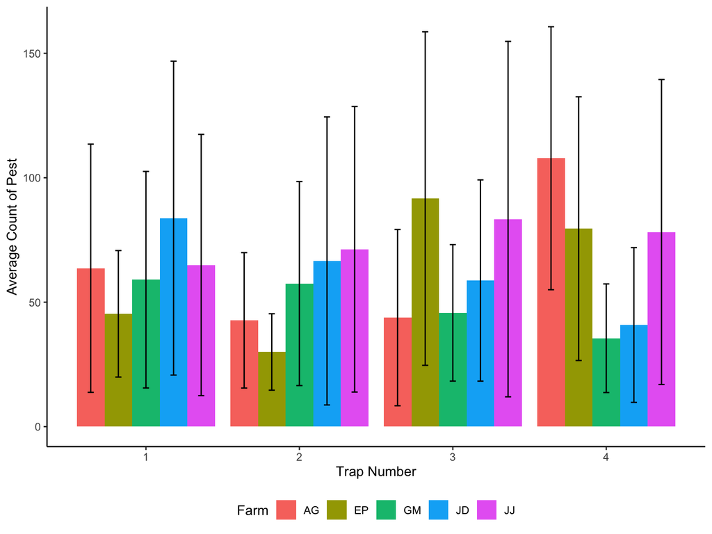

```r
# first layer is what's x, y, color
ggplot(DF_long, # data
       aes(x = Trap, # x axis
           y = Count, # y axis
           fill = Farm)) + # fill, color, shape
  # calculate the averages from the data and add bars
  stat_summary(fun = mean, # what function to do you want to calculate
               geom = "bar", # what "geom" do you want to graph
               position = "dodge") + # don't let the bars overlap
  # calculate the confidence intervals for the means
  stat_summary(fun.data = mean_cl_normal, # confidence limits
               geom = "errorbar", # error bars or whiskers
               position = position_dodge(width = .9), # don't overlap
               width = .2) + # make them smaller than the bar
  # make it not an ugly gray graph
  theme_classic() +
  # x axis label
  xlab("Trap Number") +
  # y axis label
  ylab("Average Count of Pest") +
  # put the legend on the bottom
  theme(legend.position = "bottom")
```

# Line Graphs

- What are the values across time?

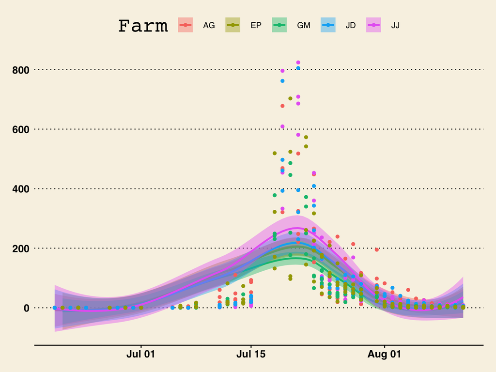

```r
# cool library of themes
library(ggthemes)
# first layer of data
ggplot(DF_long, # data
       aes(x = Date, # x axis
           y = Count, # y axis
           color = Farm,
           fill = Farm)) + # both color AND fill for this graph
  # add a line that averages across time by Farm
  geom_smooth(method = "loess") +
  # add the points to see the actual data
  geom_point() +
  # add a silly theme
  theme_wsj() +
  # notice how this is ignored
  xlab("Month") +
  ylab("Number of Pests")
```

# Stacked Bar Charts

- Are there differences in farms by month?

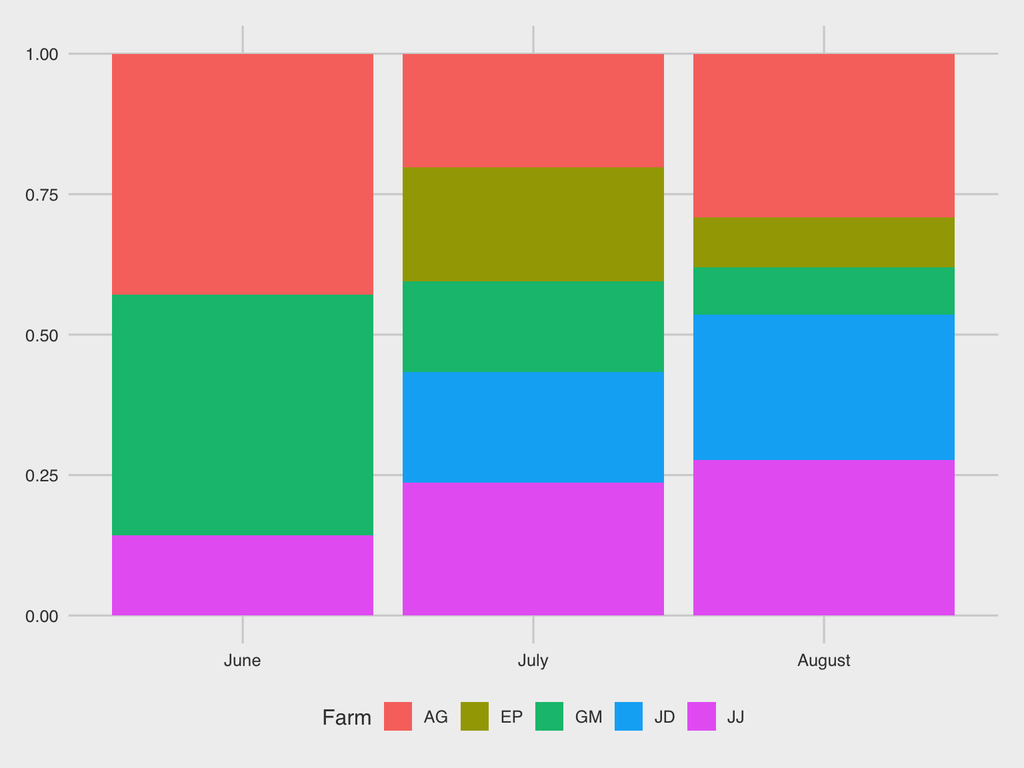

```r
# first layer of data
ggplot(DF_long %>%
         group_by(Farm, Month) %>%
         mutate(Count = sum(Count)) %>%
         select(Month, Count, Farm) %>%
         unique(), # manipulate the data by summing across months
       aes(x = Month, # x axis
           y = Count, # y axis
           fill = Farm)) + # fill by Farm
  # different silly theme
  theme_fivethirtyeight() +
  # position = fill makes this a percent chart
  geom_bar(position = "fill",
           stat = "identity") +
  # notice again, these are ignored
  xlab("Month") +
  ylab("Total Number of Pests")
```

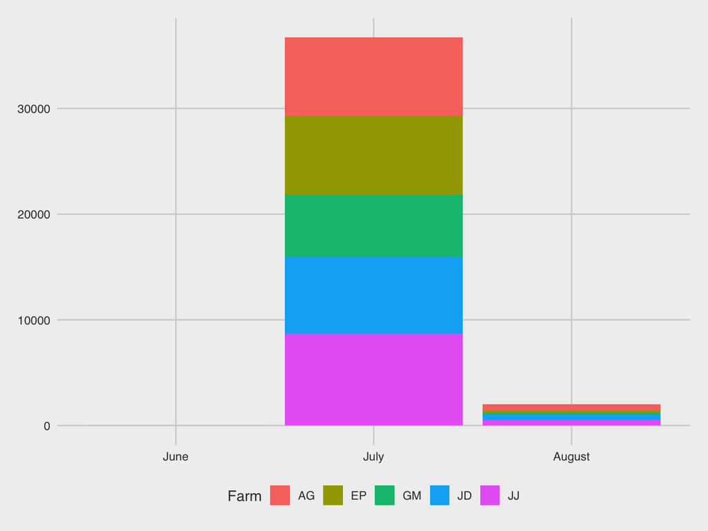

```r
# first layer of data
ggplot(DF_long %>%
         group_by(Farm, Month) %>%
         mutate(Count = sum(Count)) %>%
         select(Month, Count, Farm) %>%
         unique(), # manipulate the data by summing across months
       aes(x = Month, # x axis
           y = Count, # y axis
           fill = Farm)) + # fill by Farm
  # different silly theme
  theme_fivethirtyeight() +
  # position = stack makes this a raw count
  geom_bar(position = "stack",
           stat = "identity") +
  # notice again, these are ignored
  xlab("Month") +
  ylab("Total Number of Pests")
```

# Mosaic Charts

- There are an unbelievable number of add on packages for `ggplot2`
- Since a lot of your data is categorical, consider `treemaps` or `mosiac plots`

```r
# add on library to ggplot
library(treemapify)
# get the data
DF_pts <- import("processed_data/pts_summary.csv")
# view the data
flextable(head(DF_pts))
```

| country_map | n | n_binned | un_region_sub | un_region |
| --- | --- | --- | --- | --- |
| AD | 1 | < 100 | Southern Europe | Europe |
| AE | 20 | < 100 | Western Asia | Asia |
| AL | 3 | < 100 | Southern Europe | Europe |
| AM | 1,020 | 1000-1999 | Western Asia | Asia |
| AR | 285 | 100-999 | Latin America and the Caribbean | Americas |
| AT | 1,048 | 1000-1999 | Western Europe | Europe |

# Mosaic Charts

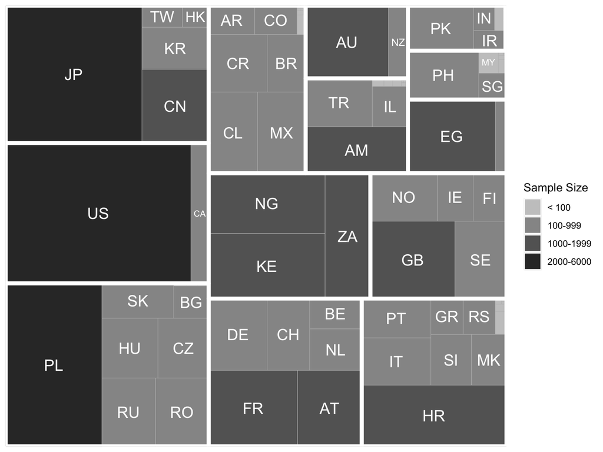

```r
# make the blank plot
ggplot(DF_pts, # data frame
       aes(area = n, # how big should the box be
           fill = n_binned, # what should we color by
           # note mine are separate because binning helped visually
           # usually those are the same
           label = country_map, # label the boxes
           subgroup = un_region_sub)) + # group by second variable
  geom_treemap() + # make a treemap
  # add a border by subgroup
  geom_treemap_subgroup_border(colour = "white", size = 5) +
  # where to put the text and what color
  geom_treemap_text(colour = "white", place = "centre",
                    size = 15, grow = FALSE) +
  # make it journal friendly by picking grays
  scale_fill_manual(name = "Sample Size",
                    values = c("#c8c8c8", "#969696", "#646464", "#323232"))
```

# Other `ggplot2` addons I like

- `Rcolorbrewer`
- `GGally`
- `ggmap`
- `gganimate`
- `ggthemes`
- `ggpubr`

# Fin

- You have learned all the things!

[figure not shown]

Buchanan, Erin Michelle, Kelly Cuccolo, Nicholas Alvaro Coles, Tom Heyman, Aishwarya Iyer, Neil Anthony Lewis, Kim Olivia Peters, et al. 2021. “Measuring the Semantic Priming Effect Across Many Languages,” December. https://doi.org/10.31219/osf.io/q4fjy.

Hutchison, Keith A., David A. Balota, James H. Neely, Michael J. Cortese, Emily R. Cohen-Shikora, Chi-Shing Tse, Melvin J. Yap, Jesse J. Bengson, Dale Niemeyer, and Erin Buchanan. 2013. “The Semantic Priming Project.” *Behavior Research Methods* 45 (4): 1099–1114. https://doi.org/10.3758/s13428-012-0304-z.

[^1]: This is a footnote